# Unsupervised learning: PCA & CA

# Introduction

In this practical, we will learn how to use principal components analysis and correspondence analysis.

We will use the package `ca`. For this, you will probably need to `install.packages("ca")` before running the `library()` functions.

```r
library(ISLR)
library(tidyverse)
library(ca)
```

# Principal components analysis

1. **Load the questionnaire dataset and explore it.**

```r
ques_df <- read_csv("data/questionnaire.csv")

ques_df
```

| BIGF1 | BIGF3 | BIGF4 | BIGFe5 | BIGF7 | BIGF10 | BIGF11 | BIGF13 | BIGF14 | BIGF15 | EMPATHY1 | EMPATHY3 | EMPATHY4 | EMPATHY6 | EMPATHY7 | EMPATHY8 | EMPATHY9 | EMPATHY12 | EMPATHY13 | EMPATHY15 | sex |
| --- | --- | --- | --- | --- | --- | --- | --- | --- | --- | --- | --- | --- | --- | --- | --- | --- | --- | --- | --- | --- |
| 5.000000 | 4.000000 | 5.000000 | 4.00000 | 5.000000 | 5.000000 | 4.000000 | 5.000000 | 5.000000 | 4.000000 | 5 | 5 | 3 | 5 | 4 | 5 | 5 | 1 | 3 | 4 | female |
| 4.000000 | 4.000000 | 1.000000 | 4.00000 | 4.000000 | 5.000000 | 4.000000 | 5.000000 | 4.000000 | 2.000000 | 5 | 1 | 3 | 5 | 5 | 3 | 5 | 5 | 3 | 5 | female |
| 1.000000 | 5.000000 | 1.000000 | 5.00000 | 5.000000 | 5.000000 | 5.000000 | 5.000000 | 5.000000 | 5.000000 | 4 | 4 | 2 | 2 | 2 | 4 | 3 | 3 | 3 | 4 | female |
| 2.000000 | 4.000000 | 4.000000 | 2.00000 | 4.000000 | 3.000000 | 3.000000 | 4.000000 | 4.000000 | 2.000000 | 3 | 1 | 2 | 3 | 3 | 3 | 3 | 2 | 3 | 3 | female |
| 4.000000 | 2.000000 | 2.000000 | 2.00000 | 4.000000 | 4.000000 | 3.000000 | 2.000000 | 4.000000 | 2.000000 | 4 | 4 | 3 | 3 | 2 | 3 | 4 | 3 | 3 | 3 | female |
| 2.000000 | 4.000000 | 4.000000 | 3.00000 | 5.000000 | 3.000000 | 3.000000 | 5.000000 | 3.000000 | 3.000000 | 5 | 5 | 5 | 4 | 4 | 4 | 5 | 4 | 4 | 3 | male |
| 4.000000 | 2.000000 | 2.000000 | 4.00000 | 4.000000 | 5.000000 | 4.000000 | 4.000000 | 4.000000 | 4.000000 | 4 | 5 | 3 | 4 | 4 | 2 | 4 | 3 | 4 | 3 | male |
| 2.000000 | 2.000000 | 3.000000 | 4.00000 | 4.000000 | 4.000000 | 4.000000 | 5.000000 | 5.000000 | 5.000000 | 5 | 3 | 3 | 1 | 2 | 1 | 3 | 4 | 2 | 4 | male |
| 2.000000 | 2.000000 | 2.000000 | 2.00000 | 4.000000 | 4.000000 | 4.000000 | 5.000000 | 4.000000 | 3.000000 | 3 | 2 | 2 | 2 | 3 | 3 | 2 | 1 | 2 | 2 | male |
| 2.000000 | 2.000000 | 3.000000 | 2.00000 | 4.000000 | 2.000000 | 3.000000 | 4.000000 | 4.000000 | 3.000000 | 4 | 1 | 1 | 3 | 3 | 2 | 2 | 3 | 1 | 2 | male |

[output cut: 519 more lines]

```r
# a lot of likert scale variables and then one sex variable
```

2. **Create a data frame with only the questionnaire columns, and standardise the dataset**

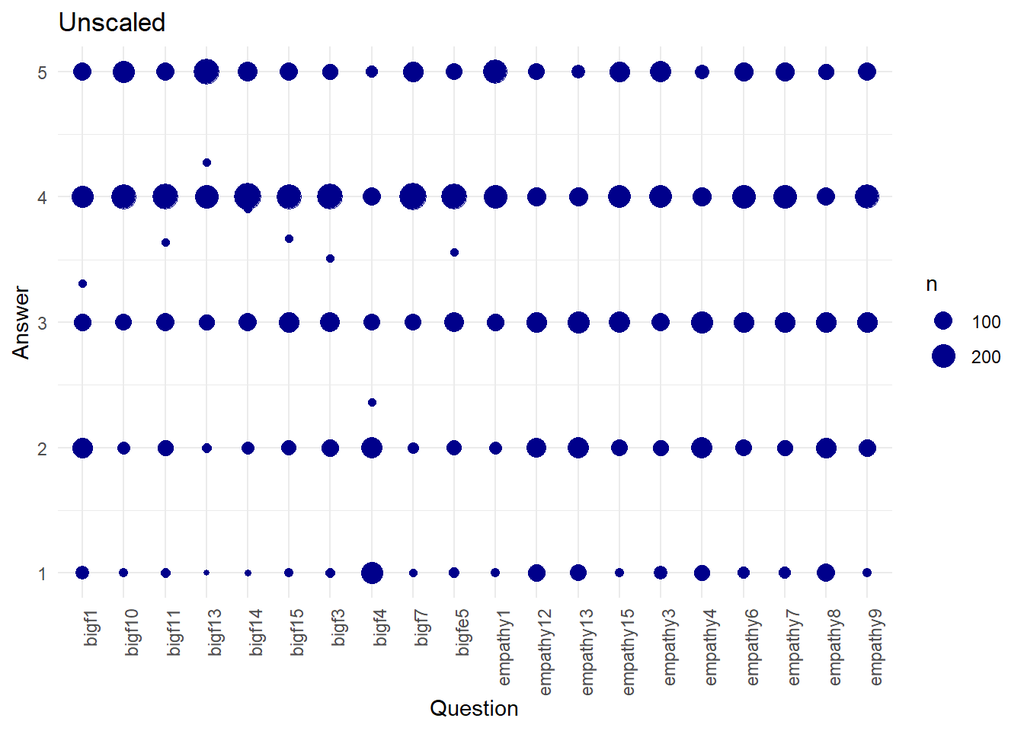

```r
ques_scaled <-
  ques_df %>%
  select(-sex) %>%
  scale() %>%
  as_tibble()

# optionally, we can also compare datasets to see what happened.
bubble_plot <- function(df) {
  df %>%
    gather(key = Question, value = Answer) %>%
    mutate(Question = str_to_lower(Question)) %>%
    ggplot(aes(x = Question, y = Answer)) +
    geom_count(colour = "#00008B") +
    theme_minimal() +
    theme(axis.text.x = element_text(angle = 90, hjust = 1))
}

# Unscaled
ques_df %>%
  select(-sex) %>%
  bubble_plot() +
  ggtitle("Unscaled")
```

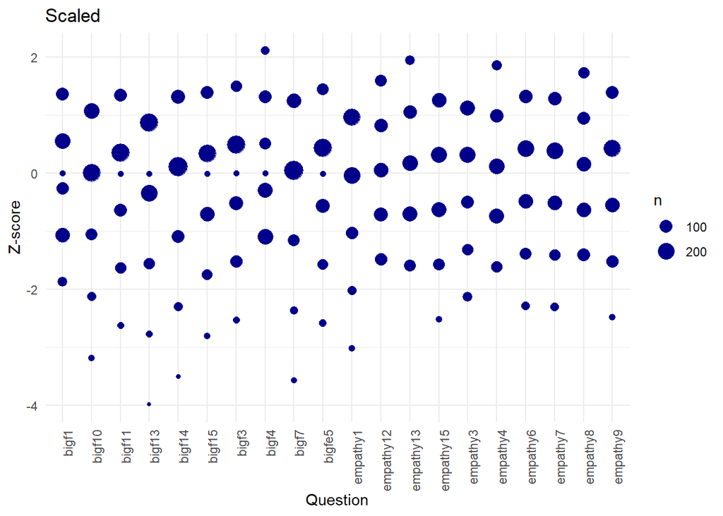

```r
# Scaled
ques_scaled %>%
  bubble_plot() +
  labs(y = "Z-score",
       title = "Scaled")
```

3. **Use the `prcomp()` function to create a principal components analysis for the scaled dataset. Save the result as `pca_mod`.**

```r
# use prcomp here?
pca_mod <- prcomp(ques_scaled)
```

4. **Are the first two principal components successful in explaining variance in the dataset? How many components do we need to explain 50% of the variation in the dataset?**

```r
summary(pca_mod)
```

```
## Importance of components:
##                          PC1    PC2    PC3     PC4     PC5     PC6     PC7
## Standard deviation     1.990 1.7203 1.2231 1.13377 1.08634 1.01829 0.93155
## Proportion of Variance 0.198 0.1480 0.0748 0.06427 0.05901 0.05185 0.04339
## Cumulative Proportion  0.198 0.3459 0.4207 0.48501 0.54402 0.59586 0.63925
##                            PC8    PC9    PC10    PC11    PC12    PC13
## Standard deviation     0.88987 0.8843 0.87713 0.80285 0.80101 0.74269
## Proportion of Variance 0.03959 0.0391 0.03847 0.03223 0.03208 0.02758
## Cumulative Proportion  0.67884 0.7179 0.75641 0.78863 0.82072 0.84829
##                           PC14    PC15   PC16    PC17   PC18    PC19
## Standard deviation     0.72226 0.69182 0.6885 0.66436 0.6418 0.59656
## Proportion of Variance 0.02608 0.02393 0.0237 0.02207 0.0206 0.01779
## Cumulative Proportion  0.87438 0.89831 0.9220 0.94408 0.9647 0.98247
##                           PC20
## Standard deviation     0.59211
## Proportion of Variance 0.01753
## Cumulative Proportion  1.00000
```

```r
# Together, the first two components explain 35% of the variance in the dataset.
# We would need 5 components to explain 50% of the variance in the dataset.
```

5. **Which original variable is most related to the first principal component? Which is the least relevant for the first principal component?**

```r
loadings_pc1 <- pca_mod$rotation[, 1]

loadings_pc1[which.max(abs(loadings_pc1))]
```

```
##    BIGF13
## 0.3182789
```

```r
# BIGF13 is the most related.

loadings_pc1[which.min(abs(loadings_pc1))]
```

```
##    EMPATHY4
## -0.02768959
```

```r
# EMPATHY4 is the least related.
```

6. **Create a scatter plot of the first two principal components. Map the sex of the respondents to the `colour` aesthetic. Is there a sex difference?**

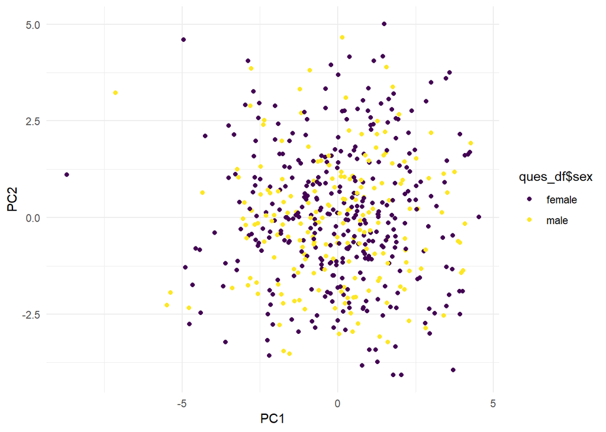

```r
as_tibble(pca_mod$x) %>%
  ggplot(aes(x = PC1, y = PC2, colour = ques_df$sex)) +
  geom_point() +
  theme_minimal() +
  scale_colour_viridis_d()
```

```r
# There does not seem to be a sex difference in the first two components
```